# HW2 Shen Ayashm

Jiacheng Chen

Sajjad Ayashm

2024-11-10

## Question 1

### Permutation Test

A permutation test is a non-parametric method used to determine if two groups differ significantly without assuming any specific distribution. This test assesses whether an observed difference could have occurred by chance.

### `median.test` Algorithm

The `median.test` function helps determine if two groups differ in their medians. It calculates the observed median difference, then permutes the combined data multiple times (default: 1,000), generating new median differences each time. By counting how often these shuffled differences are as extreme as the original, we obtain a p-value that indicates the likelihood of the observed difference occurring by chance.

### Code

```r
median.test <- function(x, y, n = 1000){
  # Check is the inputs are vector or not.
  stopifnot("the input of function should be a vector" = is.vector(x))
  stopifnot("the input of function should be a vector" = is.vector(y))

  # Calculate observed statistic
  observed_stat <- median(x) - median(y)

  # Combine data for permutation
  combine <- c(x, y)

  extreme_count = 0

  # Permutation test loop
  for (i in 1:n){
    shuffle <- sample(combine)
    perm_stat <- median(head(shuffle,length(x))) - median(tail(shuffle,length(y)))
    if (abs(perm_stat) >= abs(observed_stat)){
      extreme_count <- extreme_count + 1
    }
  }

  # Calculate p-value
  p_value <-  extreme_count / n
  return(p_value)
}
```

# Question 2:

To compare the performance of the permutation t-test, Wilcoxon–Mann–Whitney (WMW) test, and our custom median test, we set up 1,000 simulations. For each simulation, we generated two data sets (`Y1` and `Y2`) from a $t_3$-distribution, with `Y2` shifted by `delta = sqrt(3)/2` to introduce a controlled difference between groups.

Each simulation applied the three tests:

- **Permutation t-test**: p-values were calculated using `oneway_test()`.
- **Wilcoxon–Mann–Whitney test**: p-values were obtained using `wilcox.test()`.
- **Median test**: p-values were calculated with our `median.test()` function based on median differences.

The p-values were stored for each test across all simulations, allowing us to assess each test’s power to detect the simulated difference.

```r
mean(p.median < 0.05)
mean(p.t < 0.05)
mean(p.wmw < 0.05)
```

[output not shown]

After running 1,000 simulations, we calculated the power of each test based on the proportion of p-values below 0.05:

- The **Median test** had a power of approximately 44.2%.
- The **Permutation t-test** showed a power of about 40.8%.
- The **Wilcoxon–Mann–Whitney test** performed best, with a power of 52.5%.

Although results may vary slightly with each run, the general trend shows the Wilcoxon–Mann–Whitney test having the highest power, while the Median and Permutation t-tests performed similarly, with slight variations depending on data characteristics.

# Question 3:

In question 3, we explore how effective three statistical tests—the permutation t-test, the Wilcoxon–Mann–Whitney test, and our custom median test—are at detecting differences across various data distributions. To do this, we simulate data from seven different distributions and apply a set difference (delta) to compare how often each test identifies this difference. The power of each test, shown as the percentage of times it correctly detects a difference (p-value below 0.05), is summarized in the plot below, allowing us to see how each test performs with different types of data.

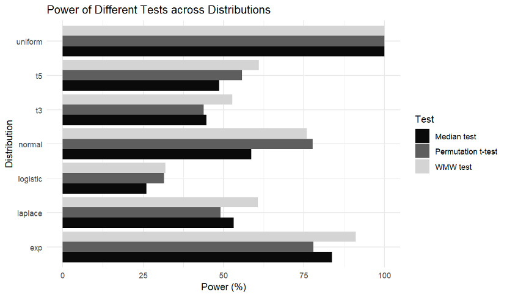

Power of Different Tests across Distributions

# Question 4:

In question 4, we’re looking at how often each test incorrectly finds a difference when there actually isn’t one, known as the Type I error rate. To do this, we set the effect size (`delta`) to zero, meaning there’s no real difference between the two groups. By seeing how often each test gives a p-value below 0.05 in this setup, we can understand how likely each test is to produce a false positive across different distributions. The chart below shows these error rates, giving us insight into each test’s reliability when there’s truly no difference to detect.

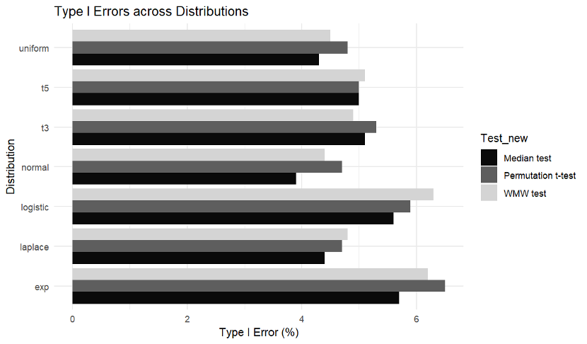

Type I Errors across Distributions

## Question 5

### i. Power Comparison:

In terms of power, the performance of each test varies significantly depending on the tail behavior of the distribution.

- For distributions with heavy tails (e.g., Laplace and exponential distributions), the Median test and Wilcoxon-Mann-Whitney (WMW) test exhibit relatively higher power than the permutation t-test. However, among these two, the WMW test tends to have slightly higher power than the Median test.
- For distributions with lighter tails (e.g., the normal distribution), the permutation t-test outperforms both the Median test and the WMW test in terms of power. Specifically, in these cases, the Median test has the lowest power of the three.

These differences are likely due to the fact that the permutation t-test relies on sample means as test statistics. Heavy-tailed distributions are more prone to outliers, which increase the variability of sample means, thereby reducing the power of the permutation t-test. In contrast, the Median and WMW tests are less sensitive to outliers, which makes them more robust and powerful in heavy-tailed distributions.

### ii. Type I Error Comparison:

When comparing Type I error rates, the tail behavior of the distribution again plays a significant role:

- Heavy-tailed distributions (e.g., logistic and exponential distributions) tend to produce higher Type I error rates than light-tailed distributions, such as the normal distribution.
- Among the three tests within the same distribution, the Median test generally exhibits the lowest Type I error rate across distributions. Notably, for the normal distribution, the Type I error rate is minimized at approximately 3.8%, making it the most conservative among the distributions studied.

This suggests that the Median test is more reliable when controlling for Type I error, particularly in heavy-tailed distributions where other tests might be more prone to false positives.

### Recommendations: When to Use the Median Test

- **For maximizing power**: The Median test is recommended primarily for heavy-tailed distributions, such as the exponential and Laplace distributions. However, if the goal is to maximize power without consideration of tail heaviness, the WMW test may be preferable due to its slightly higher power in these cases.
- **For minimizing Type I error**: The Median test is highly recommended when the goal is to achieve minimal Type I error rates. It demonstrates consistently low Type I error across various distributions, making it a conservative choice with no strict requirements on distribution type.

In practice, the choice to use the Median test should consider both power and Type I error objectives, with an understanding that the test is particularly advantageous for heavy-tailed distributions and situations where Type I error control is a priority.

# Question 6:

We completed this homework as a team, working closely together on each part of the project. From developing code and running simulations to analyzing results and interpreting our findings, we both contributed equally along the way. We discussed our approach at every step to ensure accuracy and understanding, so each analysis reflects our combined efforts.

We also worked together on writing and reviewing the report, aiming to make the explanations as clear and straightforward as possible. Overall, this homework is truly a product of our collaboration and shared dedication.